# Lab-4

eagbozo@urfu.ru

## Plotting Maps (Raster)

For this lab, we will be working with Raster Data Models

```r
library(raster)
library(spData)
library(spDataLarge)
```

We will be creating **raster layer**s Read more about Digital Elevation Models (DEM) https://www.usgs.gov/centers/eros/science/usgs-eros-archive-digital-elevation-shuttle-radar-topography-mission-srtm-1-arc?qt-science_center_objects=0#qt-science_center_objects

Here also: https://www.neonscience.org/raster-data-r

Load the file. Go to the **spDataLarge** package folder inside the -> **raster** folder -> there’s a file **srtm.tif**

```r
raster_filepath = system.file("raster/srtm.tif", package = "spDataLarge")
new_raster = raster(raster_filepath)
```

we are able to view the contents of our raster layer. it will output the raster header (extent, dimensions, resolution, CRS) andsome additional information (class, data source name, summary of the raster values)

```r
new_raster
```

```
## class      : RasterLayer
## dimensions : 457, 465, 212505  (nrow, ncol, ncell)
## resolution : 0.0008333333, 0.0008333333  (x, y)
## extent     : -113.2396, -112.8521, 37.13208, 37.51292  (xmin, xmax, ymin, ymax)
## crs        : +proj=longlat +datum=WGS84 +no_defs +ellps=WGS84 +towgs84=0,0,0
## source     : C:/Users/user/Documents/R/win-library/3.6/spDataLarge/raster/srtm.tif
## names      : srtm
## values     : 1024, 2892  (min, max)
```

Return the dimensions of the raster file (rows, columns and layers)

```r
dim(new_raster)
```

```
## [1] 457 465   1
```

view the number of cells (pixels)

```r
ncell(new_raster)
```

```
## [1] 212505
```

the raster’s spatial resolution ( a term that refers to the number of pixels utilized in construction of a digital image) The spatial extent of a data resource is a bounding box (defined by four Latitude/Longitude coordinates) and is the smallest rectangular shape which totally encloses all of the referenced data.

CRS stands for coordinate reference system

```r
res(new_raster)
```

```
## [1] 0.0008333333 0.0008333333
```

```r
extent(new_raster)
```

```
## class      : Extent
## xmin       : -113.2396
## xmax       : -112.8521
## ymin       : 37.13208
## ymax       : 37.51292
```

```r
crs(new_raster)
```

```
## CRS arguments:
##  +proj=longlat +datum=WGS84 +no_defs +ellps=WGS84 +towgs84=0,0,0
```

##### Note: for help — use the command help(“raster-package”)

let’s plot a basic map (**plot()** / **spplot()**)

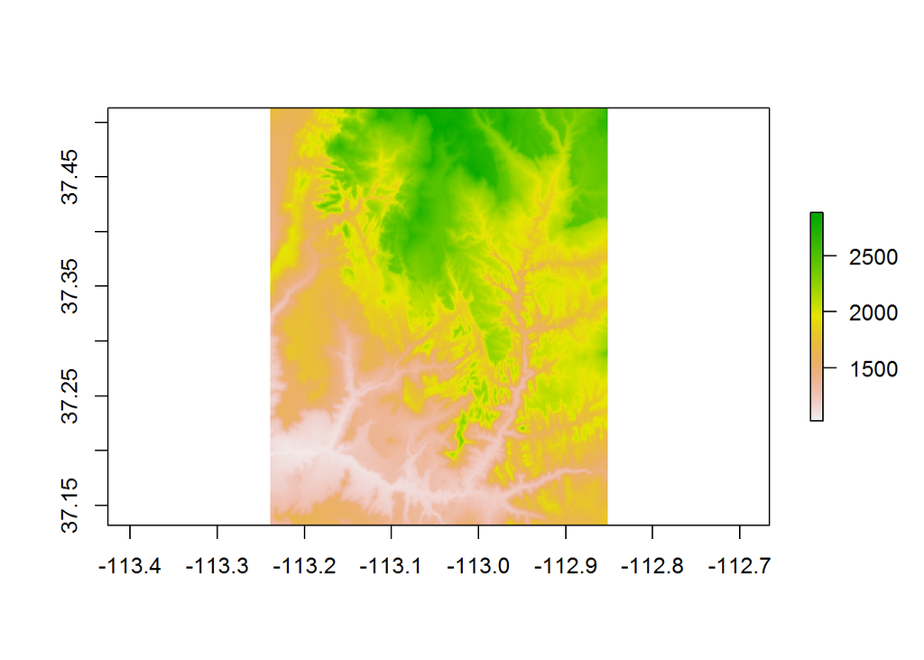

```r
plot(new_raster)
```

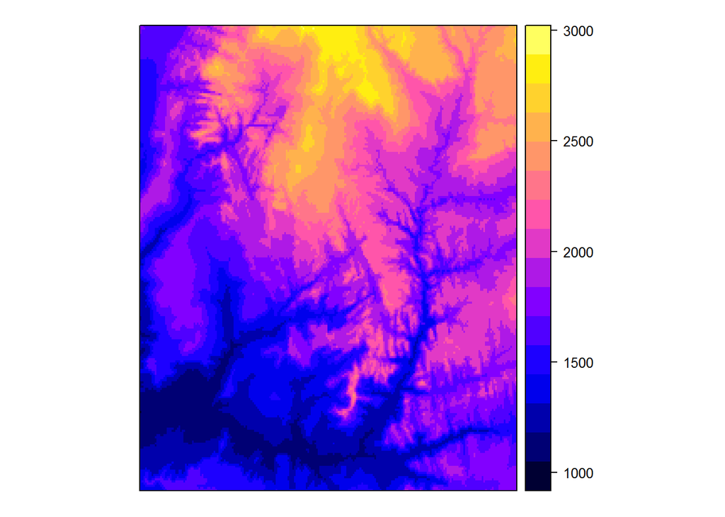

```r
spplot(new_raster)
```

Create a plot with contours of our raster

```r
library(rasterVis)
```

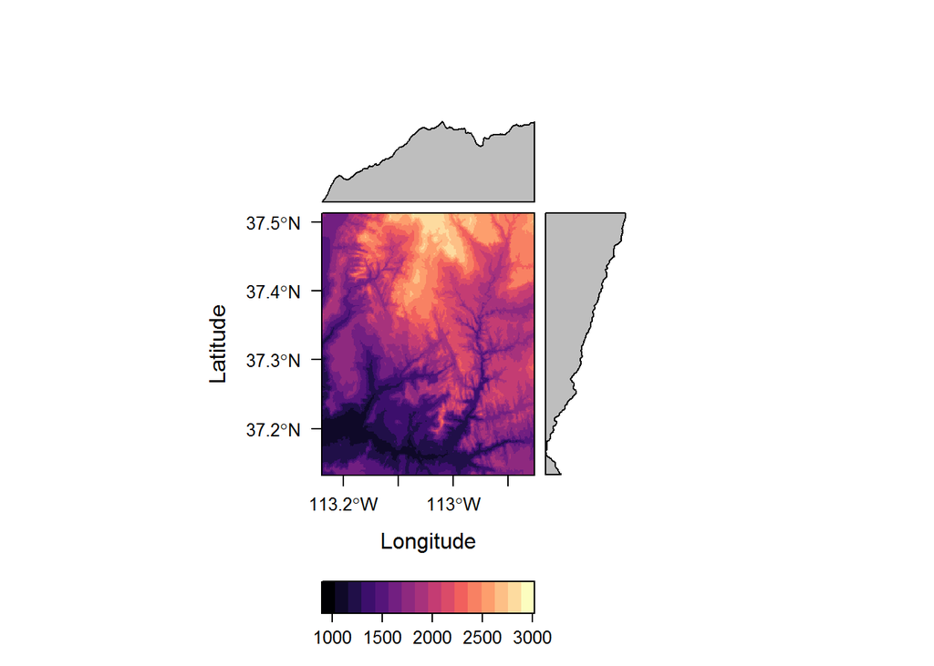

```r
#a simple level plot
levelplot(new_raster)
```

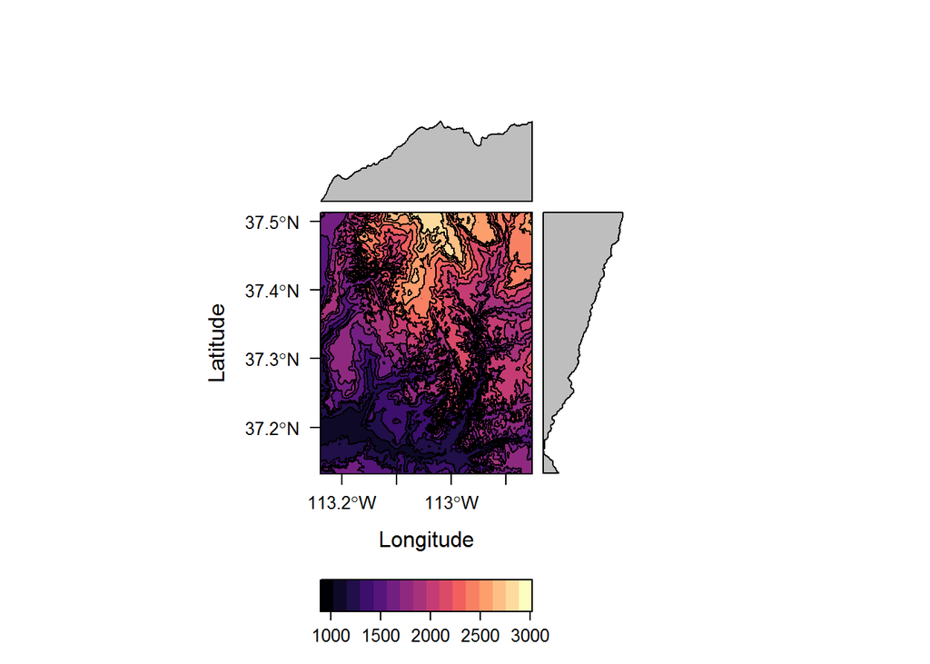

```r
levelplot(new_raster, contour=T)
```

we can also explore packages such as tmap, mapview and leaflet to create interactive maps of raster and vector objects

The RasterLayer class represents the simplest form of a raster object, and consists of only one layer. The easiest way to create a raster object in R is to read-in a raster file from disk or from a server.

##### Create a custom raster to understand the concept

```r
new_raster2 = raster(nrows = 6, ncols = 6, res = 0.5,
                     xmn = -1.5, xmx = 1.5, ymn = -1.5, ymx = 1.5,
                     vals = 1:36)
```

x-minimum, x-maximum, y-minimum, ymaximum (xmn = -1.5, xmx = 1.5, ymn = -1.5, ymx = 1.5)

You can adjust the values afterwards Plot our raster and observe the pattern (1 - 36 : the lightest colour to the brightest respectively)

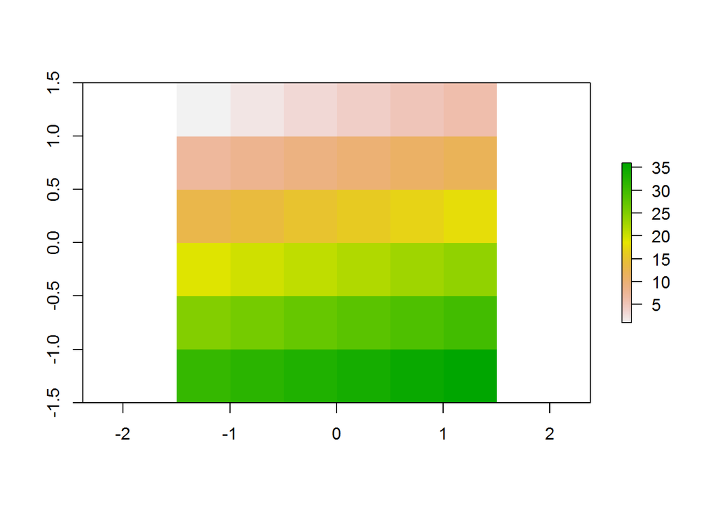

```r
plot(new_raster2)
```

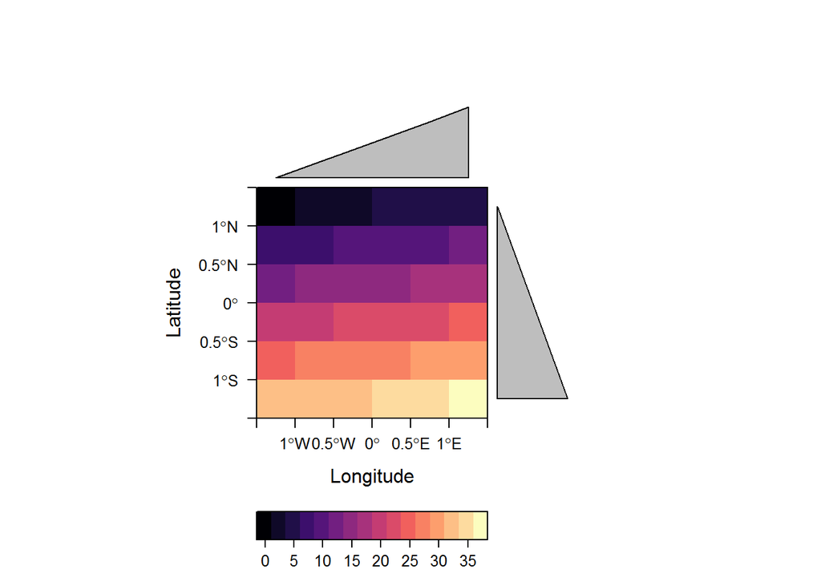

```r
levelplot(new_raster2)
```

Our plot reveals that the gradient features we see in maps are correspondent to certain figures which indicate their pixels/output.

We will load the other GEOTIF file called **landsat.tif**. It is also located in the **spDataLarge** package folder

```r
multi_raster_file = system.file("raster/landsat.tif", package = "spDataLarge")
r_brick = brick(multi_raster_file)

r_brick
```

```
## class      : RasterBrick
## dimensions : 1428, 1128, 1610784, 4  (nrow, ncol, ncell, nlayers)
## resolution : 30, 30  (x, y)
## extent     : 301905, 335745, 4111245, 4154085  (xmin, xmax, ymin, ymax)
## crs        : +proj=utm +zone=12 +datum=WGS84 +units=m +no_defs +ellps=WGS84 +towgs84=0,0,0
## source     : C:/Users/user/Documents/R/win-library/3.6/spDataLarge/raster/landsat.tif
## names      : landsat.1, landsat.2, landsat.3, landsat.4
## min values :      7550,      6404,      5678,      5252
## max values :     19071,     22051,     25780,     31961
```

```r
nlayers(r_brick)
```

```
## [1] 4
```

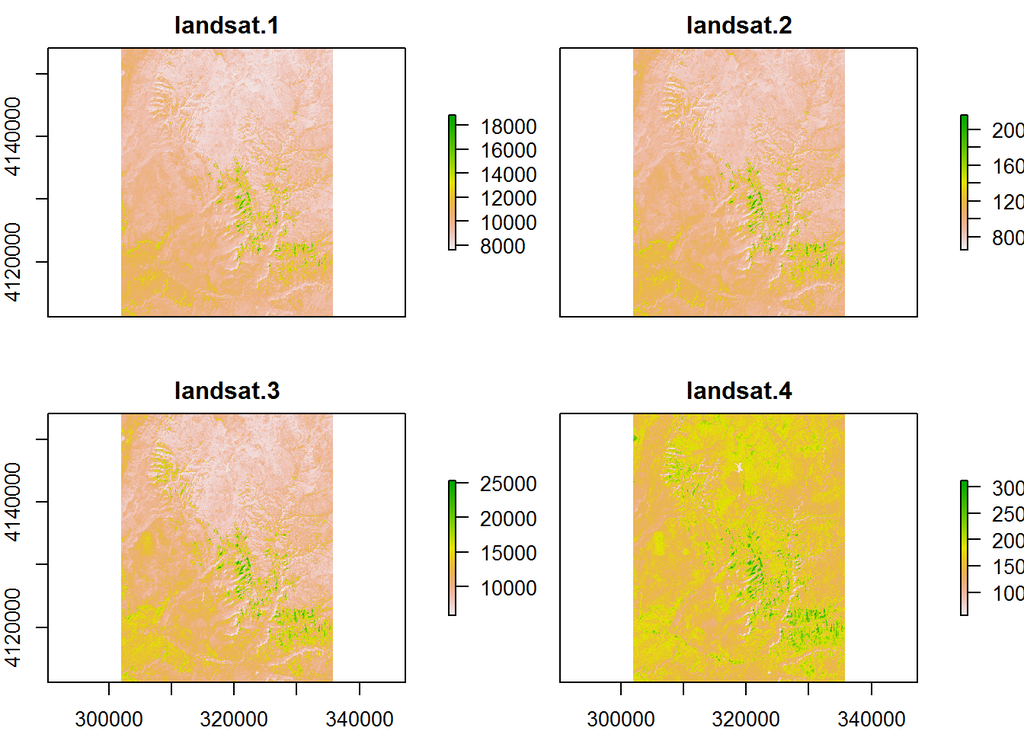

```r
plot(r_brick)
```

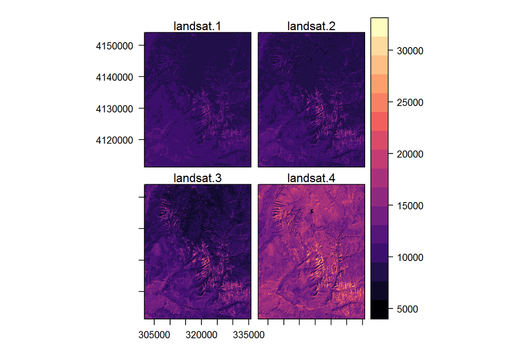

```r
levelplot(r_brick)
```

Now, let’s try this for for Yekaterinburg (Look for Yekaterinburg from : http://srtm.csi.cgiar.org/srtmdata/)

**Shuttle Radar Topography Mission (SRTM) Data** SRTM data can be used to provide topography information, relief shading, and elevation profiles for trails and routes [1].

To access any country/city/area’s raster we will be working with the **.TIF** file type.

Visit this link below: http://srtm.csi.cgiar.org/srtmdata/ - Select the desired location (Zoom into the map for more details). - Click on the area you want to work on and *search* - Options: 1. **Tile 5 x 5 degree** 2. **Geo TIFF** - Search - Take a look at the metadata. - Download the **SRTM** file - Unzip the file and copy the **.tif** file into your R project folder.

I named my file *ekb.tif*

```r
ekb_file = "ekb/ekb.tif"
ekb_raster = raster(ekb_file)

#view details
ekb_raster
```

```
## class      : RasterLayer
## dimensions : 6000, 6000, 3.6e+07  (nrow, ncol, ncell)
## resolution : 0.0008333333, 0.0008333333  (x, y)
## extent     : 60, 65, 55, 60  (xmin, xmax, ymin, ymax)
## crs        : +proj=longlat +datum=WGS84 +no_defs +ellps=WGS84 +towgs84=0,0,0
## source     : C:/Users/user/Documents/R/spatial_analytics/ekb/ekb.tif
## names      : ekb
## values     : -32768, 32767  (min, max)
```

```r
nlayers(ekb_raster)
```

```
## [1] 1
```

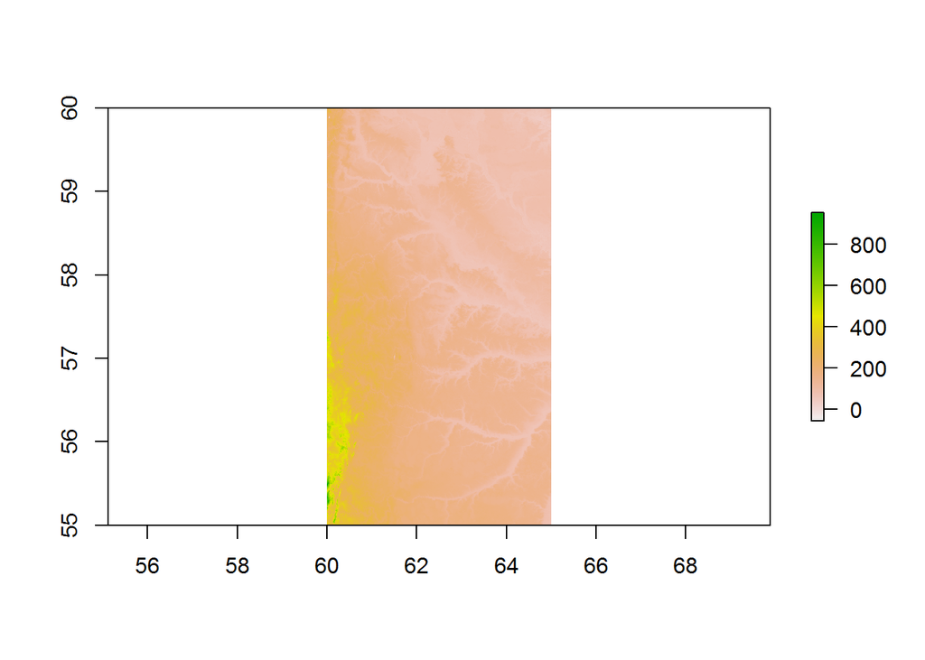

```r
plot(ekb_raster)
```

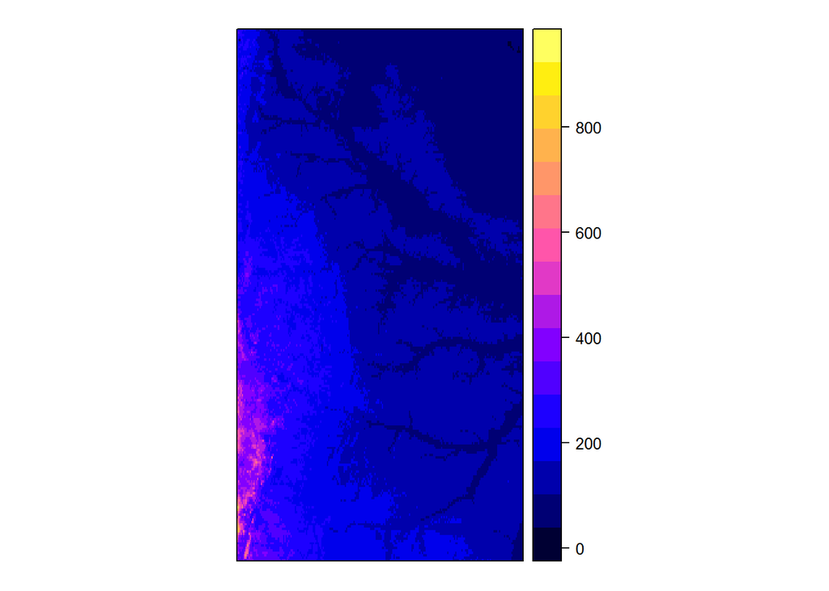

```r
spplot(ekb_raster)
```

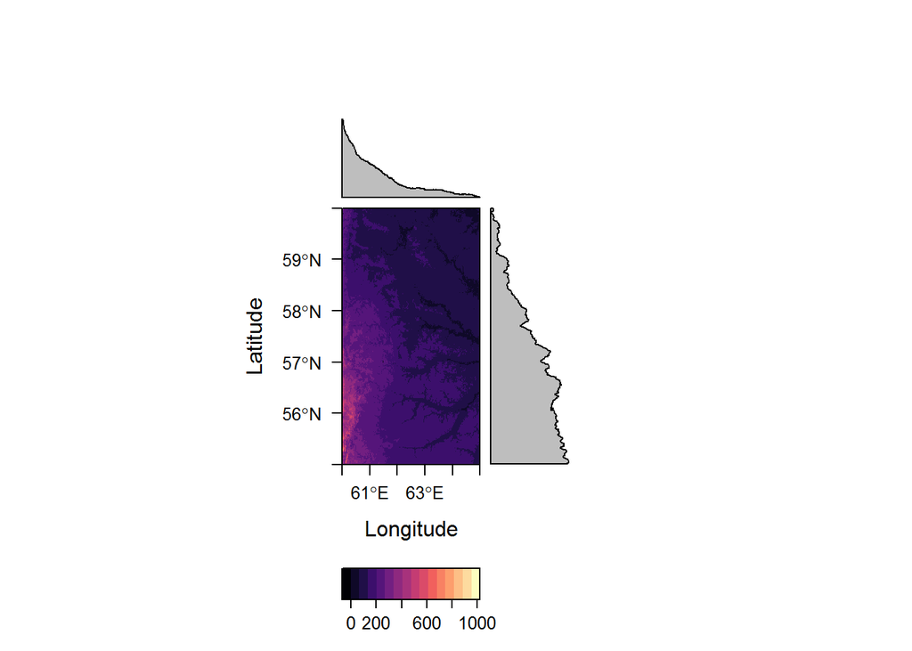

```r
levelplot(ekb_raster)
```